# Trabalho Final

Alexandre Novaes Dornelas José Carlos Maria Júnior Thiago Itamar Plum Walter Alves Moreira Barbosa dos Santos Ygor Silva Nascimento Coelho

# Análise Exploratória de Dados

## Preparação do ambiente e carregamento de bibliotecas

Esse passo é feito uma única vez para todo o script. Destaca-se que, a depender da instalação do usuário, pode ser necessária a instalação de pacotes adicionais. O comando a seguir “ativa” as funções do pacote.

```r
library(readxl)
library(dplyr)      # Manipulação e transformação de dados
library(ggplot2)    # Visualização de dados
library(ggpubr)     # Gráficos estatísticos (ex: QQ-plots)
library(patchwork)  # Combinação de gráficos
library(naniar)     # Visualização de dados faltantes
library(visdat)     # Visualização estrutural da base
library(gtsummary)  # Tabelas descritivas formatadas
library(epiR)       # Intervalos de confiança e análises epidemiológicas
library(DescTools)  # Testes estatísticos adicionais
library(vcd)        # Associação entre variáveis categóricas
library(car)        # Para VIF (multicolinearidade)
library(olsrr)      # Para testes de pressupostos (Homocedasticidade)
library(lmtest)
library(knitr)
library(kableExtra)
```

Em seguida, carregamos a base de dados fornecida para realizar a Análise Exploratória de Dados. A função read_excel() lê o arquivo e o armazena na variável ‘dados’. Em seguida, iremos checar que o “tibble” foi carregado corretamente.

```r
dados <- read_excel("Base_trabalho.xlsx")
dados
```

```
## # A tibble: 200 × 8
##    idade escolaridade reincidente filhos  sexo tempo_preso casado
##    <dbl> <chr>              <dbl>  <dbl> <dbl>       <dbl>  <dbl>
##  1    60 1                      0      0     1          58      0
##  2    60 3                      0      0     1          63      1
##  3    30 3                      1      0     1          52      0
##  4    63 2                      0      1     1          66      1
##  5    33 1                      0      1     1          45      0
##  6    53 2                      0      0     0          76      0
##  7    48 2                      0      0     1          70      0
##  8    43 2                      1      1     1          68      1
##  9    49 2                      0      1     0          45      0
## 10    36 2                      1      0     1          74      0
## # ℹ 190 more rows
## # ℹ 1 more variable: score_periculosidade <dbl>
```

| A partir dessa etapa, considera-se a preparação do ambiente terminada. |
| --- |

## Normalização dos Dados

Considerando as colunas que possuem dados numéricos, vamos realizar a padronização e normalização dos dados, convertendo as variáveis binárias para fatores com rótulos.

```r
dados <- dados |>
  mutate(
    sexo = factor(x = sexo,
                  levels = c(0, 1),
                  labels = c("Masculino", "Feminino")),
    filhos = factor(x = filhos,
                    levels = c(0, 1),
                    labels = c("Não", "Sim")),
    escolaridade = factor(x = escolaridade,
                          levels = c(1, 2, 3),
                          labels = c("Fundamental","Médio", "Superior")),
    casado = factor(x = casado,
                    levels = c(0, 1),
                    labels = c("Não", "Sim")),

    reincidente = factor(x = reincidente,
                    levels = c(0, 1),
                    labels = c("Não", "Sim"))
  )
```

## Verificação do carregamento dos dados

Vamos proceder à verificação preliminar dos nomes das colunas, bem como à sumarização dos dados.

```r
names(dados)
```

```
## [1] "idade"                "escolaridade"         "reincidente"
## [4] "filhos"               "sexo"                 "tempo_preso"
## [7] "casado"               "score_periculosidade"
```

```r
summary(dados)
```

```
##      idade            escolaridade reincidente filhos           sexo
##  Min.   :18.00   Fundamental:93    Não:162     Não: 96   Masculino: 62
##  1st Qu.:34.00   Médio      :66    Sim: 38     Sim:104   Feminino :138
##  Median :52.00   Superior   :41
##  Mean   :50.91
##  3rd Qu.:64.25
##  Max.   :97.00
##   tempo_preso    casado    score_periculosidade
##  Min.   :37.00   Não:126   Min.   : 91.05
##  1st Qu.:53.75   Sim: 74   1st Qu.:155.70
##  Median :60.50             Median :177.21
##  Mean   :60.59             Mean   :174.52
##  3rd Qu.:67.00             3rd Qu.:191.12
##  Max.   :88.00             Max.   :247.07
```

# Questão 1:

Podemos afirmar que o score médio de periculosidade é superior a 170 pontos? Utilize um nível de significância de 5%. Caso a média seja significativamente maior que 170, apresente também o intervalo de confiança de 95% correspondente.

## 1. Análise Exploratória de Dados (EDA)

Primeiro, verifica-se a distribuição com um histograma.

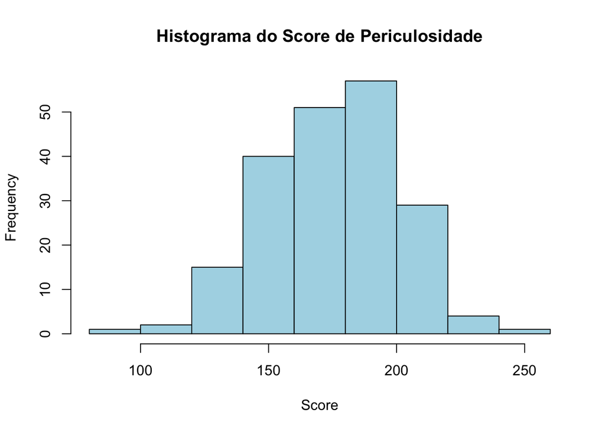

```r
# Histograma
hist(dados$score_periculosidade,
     main="Histograma do Score de Periculosidade",
     xlab="Score",
     col="lightblue",
     border="black")
```

O histograma mostra uma distribuição aparentemente simétrica. Agora, calcula-se as principais medidas numéricas:

```r
summary(dados$score_periculosidade)
```

```
##    Min. 1st Qu.  Median    Mean 3rd Qu.    Max.
##   91.05  155.70  177.21  174.52  191.12  247.07
```

A média da amostra é 174.52, o que é um indício de que a média real pode ser, sim, superior a 170.

## 2. Teste de Hipótese Formal

Aplicando o Teste t de Student.

- **$H_0$ (Hipótese Nula):** Média $\le$ 170
- **$H_1$ (Hipótese Alternativa):** Média > 170
- **Alpha:** 0.05

```r
t.test(
  dados$score_periculosidade,
  mu = 170,
  alternative = "greater"
)
```

```
##
##  One Sample t-test
##
## data:  dados$score_periculosidade
## t = 2.4874, df = 199, p-value = 0.006845
## alternative hypothesis: true mean is greater than 170
## 95 percent confidence interval:
##  171.5172      Inf
## sample estimates:
## mean of x
##  174.5206
```

## 3. Conclusão da Questão 1

O teste retornou um **p-valor = 0.006845**.

Como o p-valor (0.0068) é **menor** que o nível de significância (0.05), **rejeita-se a Hipótese Nula**.

> **Resposta:** Sim, existem evidências estatísticas suficientes para afirmar que o score médio de periculosidade é superior a 170 pontos. O intervalo de confiança de 95% reforça esta conclusão.